# Homework11

Bailey Kretzler

4/21/2021

## Introduction

For this exercise I am going to use some recenty acquired root data. I obtained this from root scans of *Phaseolus vulgaris* using the WinRhizo software to analyze it. The out put was a .txt which I cleaned up in R in a separate file. I am going to mostly focus on root length here. I will use this data to simulate some other data and batch process that.

### Loading in Data

```r
#---------------------------------------------------------#
#                      Prelims
#---------------------------------------------------------#

library(MASS)

library(ggplot2)

library(TeachingDemos)

char2seed("Flatpicking Solo")

#---------------------------------------------------------#
#                      global variables
#---------------------------------------------------------#

file <- "RandomBeans/" # the random file we will use

nfiles <- 50 # number of files to create from the data

fileOut <- "StatsSummaryBeans.csv" #output file

#---------------------------------------------------------#
#                      load in data
#---------------------------------------------------------#

df <- read.table(file = "CleanedWin.csv", sep = ",", header = TRUE)  #root scan data

colnames(df)
```

```
##  [1] "X"                    "SampleID"             "Part"
##  [4] "AnalysedRegionArea"   "AnalysedRegionWidth"  "AnalysedRegionHeight"
##  [7] "Length"               "ProjArea"             "SurfArea"
## [10] "AvgDiam"              "LenPerVol"            "RootVolume.cm3."
## [13] "Tips"                 "Forks"                "Crossings"
## [16] "NofNodules"           "NumberOfClasses"      "L0_0.5"
## [19] "L0.5_1.0"             "L1.0_1.5"             "L1.5_2.0"
## [22] "L2.0_2.5"             "L2.5_3.0"             "L3.0_3.5"
## [25] "L3.5_4.0"             "L4.0_4.5"             "L_4.5"
## [28] "SA0_0.5"              "SA0.5_1.0"            "SA1.0_1.5"
## [31] "SA1.5_2.0"            "SA2.0_2.5"            "SA2.5_3.0"
## [34] "SA3.0_3.5"            "SA3.5_4.0"            "SA4.0_4.5"
## [37] "SA4.5"                "PA0_0.5"              "PA0.5_1.0"
## [40] "PA1.0_1.5"            "PA1.5_2.0"            "PA2.0_2.5"
## [43] "PA2.5_3.0"            "PA3.0_3.5"            "PA3.5_4.0"
## [46] "PA4.0_4.5"            "PA4.5"                "V0_0.5"
## [49] "V0.5_1.0"             "V1.0_1.5"             "V1.5_2.0"
## [52] "V2.0_2.5"             "V2.5_3.0"             "V3.0_3.5"
## [55] "V3.5_4.0"             "V4.0_4.5"             "V.4.5"
## [58] "T0_0.5"               "T0.5_1.0"             "T1.0_1.5"
## [61] "T1.5_2.0"             "T2.0_2.5"             "T2.5_3.0"
## [64] "T3.0_3.5"             "T3.5_4.0"             "T4.0_4.5"
## [67] "T4.5"                 "GT"                   "TMT"
## [70] "rep"
```

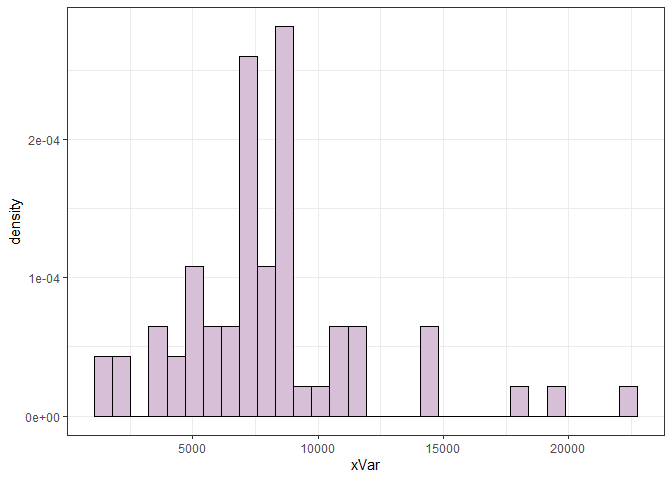

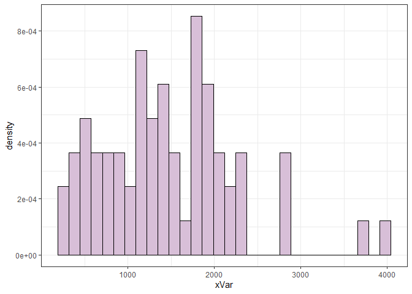

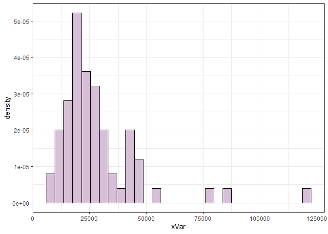

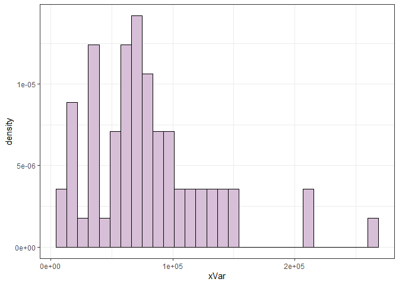

```r
#subsetting to the most relevant data
Roots <- (df[,c("SampleID","GT", "TMT", "rep","Length", "SurfArea", "Tips", "Forks")])


#---------------------------------------------------------#
#                      inspect data
#---------------------------------------------------------#


myHist <- function(xVar,filCol="thistle"){

  ggplot(data = Roots, aes(x = xVar, y = ..density..)) + geom_histogram( colour = "black", fill = "thistle") +
    theme_bw()
}

for(i in 5:8){
  p <-  myHist(Roots[,i])
  print(p)
}
```

```r
#surface are and length are best candidates

#create data frame of just these

BeanSub <- Roots[,c("Length","SurfArea")]


#---------------------------------------------------------#
#              Extracting normal parameters
#---------------------------------------------------------#


###########################################################
#------------------SEE CODE AT END-----------------------#
###########################################################



#normal distrubtion for root length
normLen <- fitdistr(Roots$Length,"normal")

#create mean and standard deviation values from fitdistr above
meanLen <- normLen$estimate["mean"]
sdLen <- normLen$estimate["sd"]


#normal dist for surface area
normSA <- fitdistr(Roots$SurfArea,"normal")

#create mean and standard deviation values from fitdistr above
meanSA <- normSA$estimate["mean"]
sdSA <- normSA$estimate["sd"]


# ---------------------------------------------------------
#                      Functions
# ---------------------------------------------------------

#----------------------------------------------------------
#FUNCTION: fileBuilder
#Description: creates a set of randome files for regression
#Inputs: fileN = number of data files to create,
#        fileFold = folder name for random files,
#        fileSize = c(min, max) min and max number of rows in file,
#        fileNA = average number of NA values per column
#Outputs: creates set of random riles
#----------------------------------------------------------
fileBuilder <- function(fileN = 10,
                        fileFold = "RandomBeans/",
                        fileSize = c(15, 100),
                        fileNA = 3) {

  for(i in seq_len(fileN)){
    fileLen <- sample(fileSize[1]:fileSize[2], size = 1)
      #creates a random file length using the rand specified by file size
      #from value 1 to value 2
    Length <- rnorm(n = fileLen, mean = meanLen, sd = sdLen) #using parameter extracted above
    SurfArea <- rnorm(n =fileLen, mean = meanSA, sd = sdSA) #using parameter extracted above
    df <- data.frame(Length, SurfArea) #bind into data frame
    badVal <- rpois(n = 1, lambda = fileNA) #determine number of NAs
    df[sample(nrow(df), size = badVal),1] <- NA
    df[sample(nrow(df), size = badVal),2] <- NA

    #create label for file name with padded zeros

    fileLab <- paste(fileFold, "RanFile",
                     formatC(i,
                             width = 3,
                             format = "d",
                             flag = "0"),
                     ".csv", sep ="")
    # set up data file and incorporate time stamp and minimal metadata

  write.table(cat("# Simulated random data file for batch processing", "\n",
                  "# timestamp: ", as.character(Sys.time()), "\n",
                  "# BMK", "\n",
                  "# ------------------------------", "\n",
                  "\n",
                  file = fileLab,
                  row.names = "",
                  col.names = "",
                  sep = ""))
  #add data frame

  write.table(x = df,
              file = fileLab,
              sep = ",",
              row.names = FALSE,
              append = TRUE)


  }#End loop


} #end of fileBuilder
#----------------------------------------------------------

#----------------------------------------------------------
#FUNCTION: regStats
#Description: fit linear mode, extract model stats
#Inputs: 2 column data fram (x and y)
#Outputs: slope, p value, and r sq
#----------------------------------------------------------
regStats <- function(d = NULL) {
      if(is.null(d)){
        x <- runif(10)
        y <- runif(10)
        d <- data.frame(x,y)
      }
  . <- lm(data = d, d[,2]~d[,1])
  . <- summary(.)
  statList <- list(slope <- .$coefficients[2,1],
                   p <- .$coefficients[2,4],
                   rsq <- .$r.squared)




  return(statList)

} #end of regStats
#----------------------------------------------------------


#---------------------------------------------------------#
#               create data frame and sets
#---------------------------------------------------------#

dir.create(file) # IF CHANGED DON'T RE RUN

write.csv(BeanSub, file = "RandomBeans/BeanSub.csv") #add real data to directory

fileBuilder(fileN = nfiles) #IF CHANGED DON'T RERUN
```

[output not shown]

```r
fileNames <- list.files(path = file)

#data frame

ID <- seq_along(fileNames)
filename <- fileNames
slope <- rep(NA, length(fileNames))
pval <- rep(NA, length(fileNames))
rsq <- rep(NA, length(fileNames))
statOut <- data.frame(ID, filename,slope, pval,rsq)

head(statOut)
```

```
##   ID       filename slope pval rsq
## 1  1    BeanSub.csv    NA   NA  NA
## 2  2 RanFile001.csv    NA   NA  NA
## 3  3 RanFile002.csv    NA   NA  NA
## 4  4 RanFile003.csv    NA   NA  NA
## 5  5 RanFile004.csv    NA   NA  NA
## 6  6 RanFile005.csv    NA   NA  NA
```

Now that everything is set up we can get on with batch processing these files!

### Batch Proccessing

```r
#---------------------------------------------------------#
#                      Batch Processing
#---------------------------------------------------------#

### loop through the individual filed and process


for(i in seq_along(fileNames)){
  data <- read.table(file = paste(file,fileNames[i],
                     sep = ""), #sep for paste
                     sep = ",",#sep for read.table
                     header = TRUE)
  dClean <- data[complete.cases(data),] # subset for clean data (no NAs)

  . <- regStats(dClean)
  statOut[i,3:5] <- unlist(.)
}


#set up output file with metadata

write.table(cat("# Summary Stats for ",
                "batch processing of regression models",
                "\n",
                "# time stamp:", as.character(Sys.time()),
                "\n",
                file = fileOut,
                row.names ="",
                col.names = "",
                sep = ""))
```

```
## ""
```

```r
#add data frame

write.table(x = statOut,
            file = fileOut,
            row.names = FALSE,
            col.names = TRUE,
            sep = ",",
            append = TRUE)


#view the head of the file to see what the model out put looks like

head(statOut)
```

```
##   ID       filename        slope      pval          rsq
## 1  1    BeanSub.csv  1.781539705 0.9466709 7.274303e-05
## 2  2 RanFile001.csv -0.012897368 0.5419181 4.291221e-03
## 3  3 RanFile002.csv  0.021399341 0.2757351 1.521159e-02
## 4  4 RanFile003.csv  0.017851638 0.3020702 1.169910e-02
## 5  5 RanFile004.csv  0.013440427 0.6968382 3.834887e-03
## 6  6 RanFile005.csv  0.005167988 0.8808088 4.731923e-04
```

```r
#most importantly look at the model output for the real data

statOut[which(statOut$filename == "BeanSub.csv"),]
```

```
##   ID    filename   slope      pval          rsq
## 1  1 BeanSub.csv 1.78154 0.9466709 7.274303e-05
```

### Fitting Distributions

This is the code I used to determine which distributions were the best for simulating the root data. They both ended up being normalish.

#### Root length

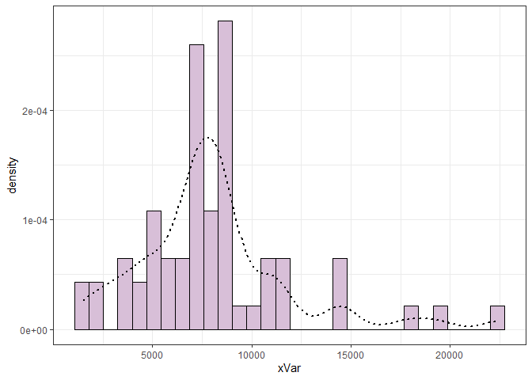

```r
 pl <- myHist(Roots$Length) # initial histogram
d<- geom_density(linetype="dotted",size=0.75) #add density geom
pl +  d # print out
```

```r
 #---------------------------------------------------------#
 #                      normal
 #---------------------------------------------------------#
#use fitdistr to fit normal distribution parameters to data
normPars <- fitdistr(Roots$Length,"normal")

#pring to view what it generated
print(normPars)
```

```
##      mean         sd
##   8040.8904   3858.6568
##  ( 482.3321) ( 341.0603)
```

```r
#view the structure
str(normPars)
```

```
## List of 5
##  $ estimate: Named num [1:2] 8041 3859
##   ..- attr(*, "names")= chr [1:2] "mean" "sd"
##  $ sd      : Named num [1:2] 482 341
##   ..- attr(*, "names")= chr [1:2] "mean" "sd"
##  $ vcov    : num [1:2, 1:2] 232644 0 0 116322
##   ..- attr(*, "dimnames")=List of 2
##   .. ..$ : chr [1:2] "mean" "sd"
##   .. ..$ : chr [1:2] "mean" "sd"
##  $ n       : int 64
##  $ loglik  : num -619
##  - attr(*, "class")= chr "fitdistr"
```

```r
#extract the mean
normPars$estimate["mean"] # note structure of getting a named attribute
```

```
##    mean
## 8040.89
```

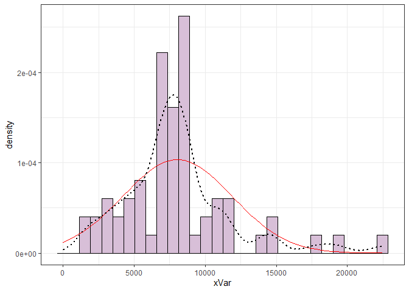

```r
#create mean and standard deviation values from fitdistr above
meanML <- normPars$estimate["mean"]
sdML <- normPars$estimate["sd"]

#creating a vector for x values to use on the graph
#zero to the max value of phoshorus
#length is the number of observations
xval <- seq(0,max(Roots$Length),len=length(Roots$Length))

#add a normal shaped line to the graph in red
 stat <- stat_function(aes(x = xval, y = ..y..), fun = dnorm, colour="red", n = length(Roots$Length), args = list(mean = meanML, sd = sdML))
 pl + stat + d
```

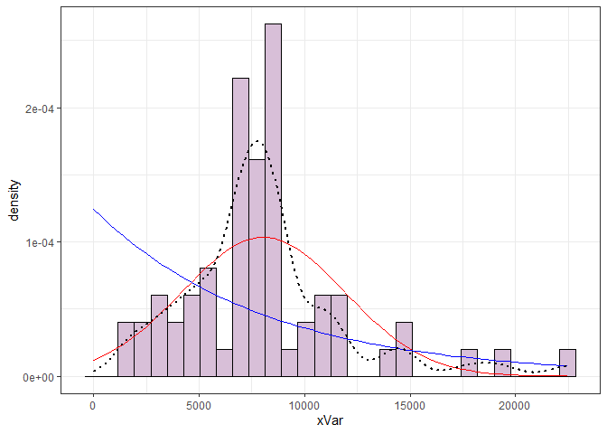

```r
 #---------------------------------------------------------#
 #                      Exponential
 #---------------------------------------------------------#

#fitdistr for exponential dis
expoPars <- fitdistr(Roots$Length,"exponential")
#extracting the rate from the estimates generated
#by fitdistr
rateML <- expoPars$estimate["rate"]

#add an exponential dist. line to the graph in blue
stat2 <- stat_function(aes(x = xval, y = ..y..), fun = dexp, colour="blue", n = length(Roots$Length), args = list(rate=rateML))
 pl + stat + stat2 + d
```

```r
#this does not match

#---------------------------------------------------------#
#                      Uniform
#---------------------------------------------------------#


#create uniform probability using data min and max in dark green
stat3 <- stat_function(aes(x = xval, y = ..y..), fun = dunif, colour="darkgreen", n = length(Roots$Length), args = list(min=min(Roots$Length), max=max(Roots$Length)))
 pl + stat + stat2 + stat3 + d
```

[figure not shown]

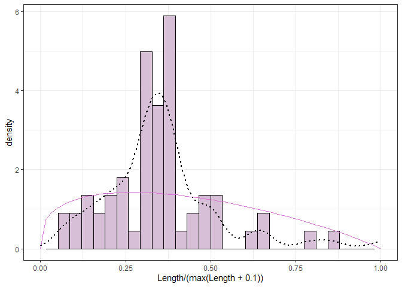

```r
 #---------------------------------------------------------#
 #                      beta
 #---------------------------------------------------------#

#creating a special graph?
#x is proportional to max value of x plus 0.1
pSpecial <- ggplot(data=Roots, aes(x=Length/(max(Length + 0.1)), y=..density..)) +
  geom_histogram(color="black",fill="thistle",size=0.2) +
  theme_bw() +
  xlim(c(0,1)) +
  geom_density(size=0.75,linetype="dotted")

#fitdistr for beta
betaPars <- fitdistr(x=Roots$Length/max(Roots$Length + 0.1),start=list(shape1=1,shape2=2),"beta")
#extract shape1
shape1ML <- betaPars$estimate["shape1"]
#extract shape 2
shape2ML <- betaPars$estimate["shape2"]


statSpecial <- stat_function(aes(x = xval, y = ..y..), fun = dbeta, colour="orchid", n = length(Roots$Length), args = list(shape1=shape1ML,shape2=shape2ML))
pSpecial + statSpecial
```

Okay so none of these really look great.. I could not get the gamma to work because of the nature of the data so I am going to stick with the normal distribution for root length. Now let’s do surface area.

#### Surface Area

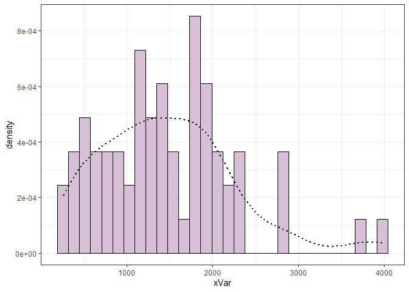

```r
 pl <- myHist(Roots$SurfArea) # initial histogram
d<- geom_density(linetype="dotted",size=0.75) #add density geom
pl +  d # print out
```

```r
 #---------------------------------------------------------#
 #                      normal
 #---------------------------------------------------------#
#use fitdistr to fit normal distribution parameters to data
normPars <- fitdistr(Roots$SurfArea,"normal")

#pring to view what it generated
print(normPars)
```

```
##       mean          sd
##   1458.92997    771.66553
##  (  96.45819) (  68.20624)
```

```r
#view the structure
str(normPars)
```

```
## List of 5
##  $ estimate: Named num [1:2] 1459 772
##   ..- attr(*, "names")= chr [1:2] "mean" "sd"
##  $ sd      : Named num [1:2] 96.5 68.2
##   ..- attr(*, "names")= chr [1:2] "mean" "sd"
##  $ vcov    : num [1:2, 1:2] 9304 0 0 4652
##   ..- attr(*, "dimnames")=List of 2
##   .. ..$ : chr [1:2] "mean" "sd"
##   .. ..$ : chr [1:2] "mean" "sd"
##  $ n       : int 64
##  $ loglik  : num -516
##  - attr(*, "class")= chr "fitdistr"
```

```r
#extract the mean
normPars$estimate["mean"] # note structure of getting a named attribute
```

```
##    mean
## 1458.93
```

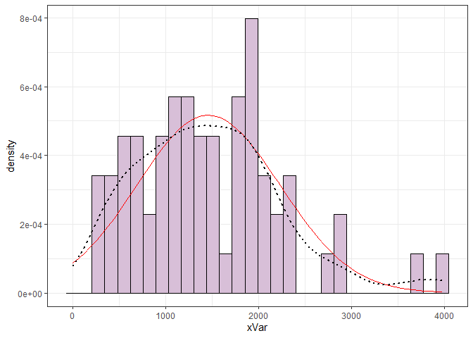

```r
#create mean and standard deviation values from fitdistr above
meanML <- normPars$estimate["mean"]
sdML <- normPars$estimate["sd"]

#creating a vector for x values to use on the graph
#zero to the max value of phoshorus
#length is the number of observations
xval <- seq(0,max(Roots$SurfArea),len=length(Roots$SurfArea))

#add a normal shaped line to the graph in red
 stat <- stat_function(aes(x = xval, y = ..y..), fun = dnorm, colour="red", n = length(Roots$SurfArea), args = list(mean = meanML, sd = sdML))
 pl + stat + d
```

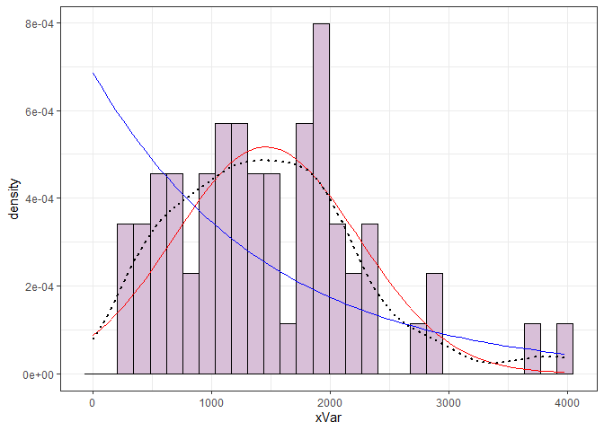

```r
 #---------------------------------------------------------#
 #                      Exponential
 #---------------------------------------------------------#

#fitdistr for exponential dis
expoPars <- fitdistr(Roots$SurfArea,"exponential")
#extracting the rate from the estimates generated
#by fitdistr
rateML <- expoPars$estimate["rate"]

#add an exponential dist. line to the graph in blue
stat2 <- stat_function(aes(x = xval, y = ..y..), fun = dexp, colour="blue", n = length(Roots$SurfArea), args = list(rate=rateML))
 pl + stat + stat2 + d
```

```r
#this does not match

#---------------------------------------------------------#
#                      Uniform
#---------------------------------------------------------#


#create uniform probability using data min and max in dark green
stat3 <- stat_function(aes(x = xval, y = ..y..), fun = dunif, colour="darkgreen", n = length(Roots$SurfArea), args = list(min=min(Roots$SurfArea), max=max(Roots$SurfArea)))
 pl + stat + stat2 + stat3 + d
```

[figure not shown]

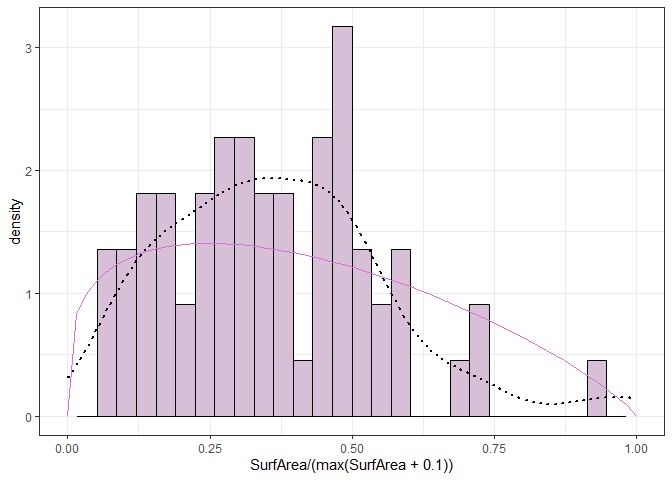

```r
 #---------------------------------------------------------#
 #                      beta
 #---------------------------------------------------------#

#creating a special graph?
#x is proportional to max value of x plus 0.1
pSpecial <- ggplot(data=Roots, aes(x=SurfArea/(max(SurfArea + 0.1)), y=..density..)) +
  geom_histogram(color="black",fill="thistle",size=0.2) +
  theme_bw() +
  xlim(c(0,1)) +
  geom_density(size=0.75,linetype="dotted")

#fitdistr for beta
betaPars <- fitdistr(x=Roots$SurfArea/max(Roots$SurfArea + 0.1),start=list(shape1=1,shape2=2),"beta")
#extract shape1
shape1ML <- betaPars$estimate["shape1"]
#extract shape 2
shape2ML <- betaPars$estimate["shape2"]


statSpecial <- stat_function(aes(x = xval, y = ..y..), fun = dbeta, colour="orchid", n = length(Roots$SurfArea), args = list(shape1=shape1ML,shape2=shape2ML))
pSpecial + statSpecial
```

Again the normal is the best option since I cannot figure out the gamma distribution.